# Earth’s oxygenation recorded in genomes (2025)

This vignette runs the functions to make the plots from the following manuscript:

> Dick JM. 2025. Earth’s oxygenation recorded in genomes. Manuscript in preparation.

This vignette was compiled on 2025-05-20 with **JMDplots** 1.2.22, **canprot** 2.0.0, and **[CHNOSZ](http://chnosz.net)** 2.1.0-72.

```r
library(JMDplots)
```

## Genome-wide differences of oxidation state between two lineages of methanogens (Figure 1)

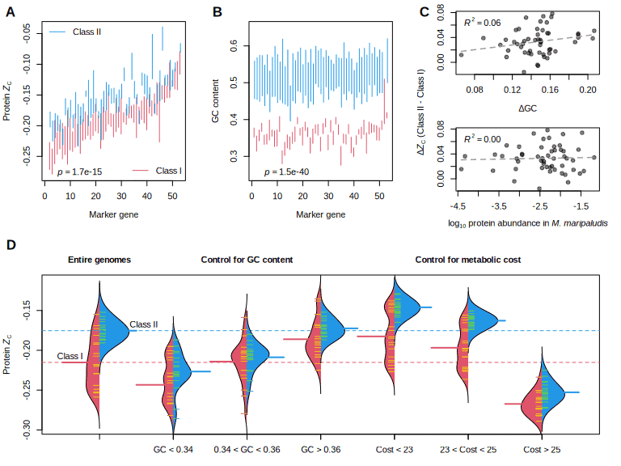

```r
genoGOE_1()
```

**Data sources:** List of Class I and II methanogen species (Lyu and Lu, 2018), archaeal marker genes used in GTDB (Rinke et al., 2021), and protein abundance in *Methanococcus maripaludis* (Xia et al., 2006).

## Carbon oxidation state of proteins in eukaryotic gene age groups (Figure 2)

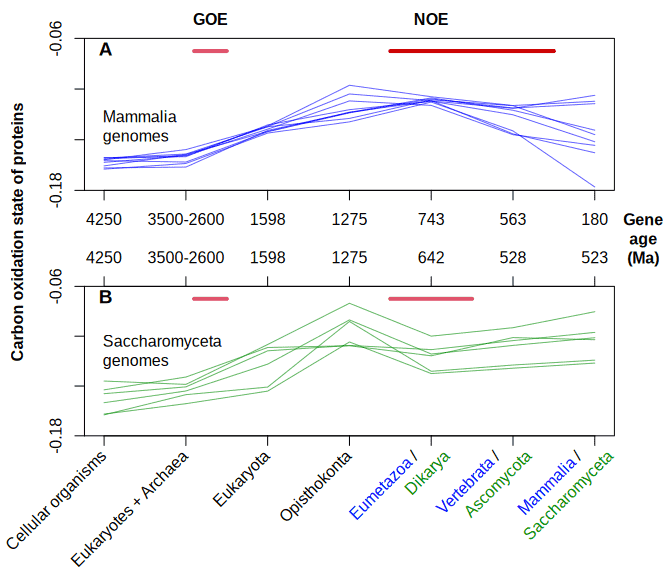

```r
genoGOE_2()
```

**Data sources:** Consensus gene ages (Liebeskind et al., 2016), protein sequences (The UniProt Consortium, 2023), and divergence times (Kumar et al., 2022).

## Evolutionary oxidation of ancestral Rubiscos and thermodynamic prediction of redox boundaries around the GOE (Figure 3)

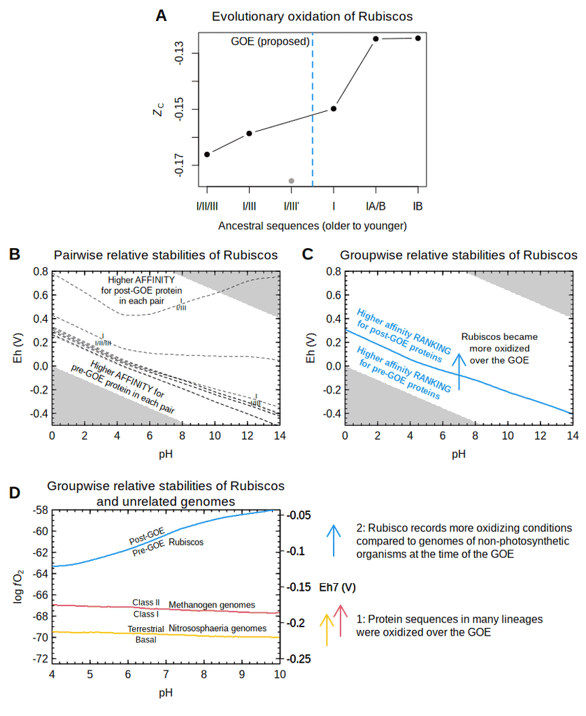

```r
genoGOE_3()
```

**Data sources:** Reconstructed ancestral sequences of Rubisco (Kaçar et al., 2017) and lists of methanogen (Lyu and Lu, 2018) and Nitrososphaeria (Ren et al., 2019) genomes.

## Evolutionary oxidation and relative stabilities for genomes with S-cycling genes (Figure 4)

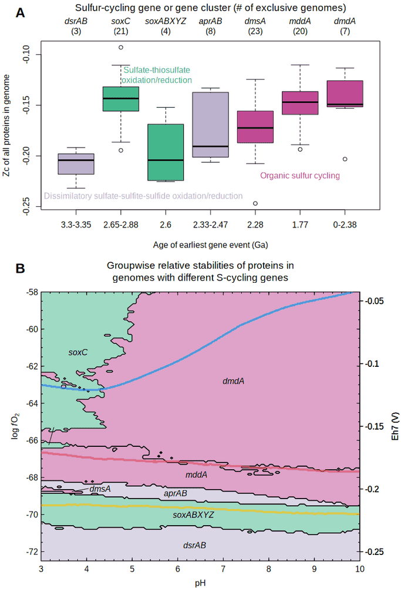

```r
genoGOE_4()
```

**Data sources:** Genomes with different S-cycling genes (Mateos et al., 2023).

## Carbon oxidation state of ancestral and extant nitrogenases (Figure 5)

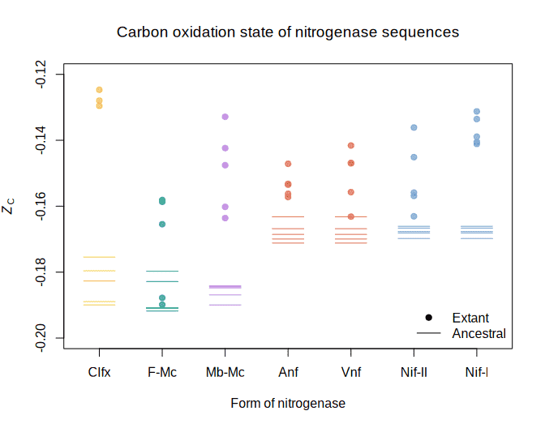

```r
genoGOE_5()
```

**Data source:** Garcia et al. (2020).

## Composition reaction for ancestral Rubisco I/II/III (Reaction 1)

```
## [1] "Eh: -0.368 volt"
```

```
## [1] "Elemental formula of protein per residue: C4.949H7.749N1.326O1.467S0.032+0.005"
```

```
## [1] "Stoichiometry of composition reaction:"
```

```
##      C5H10N2O3 C5H9NO4 C3H7NO2S    H2O    e-   H+
## [1,]     0.323   0.648    0.032 -2.157 2.828 2.78
```

```
## [1] "Affinity/2.303RT of composition reaction: -2.06"
```

## References

Garcia AK, McShea H, Kolaczkowski B, Kaçar B. 2020. Reconstructing the evolutionary history of nitrogenases: Evidence for ancestral molybdenum-cofactor utilization. *Geobiology* **18**(3): 394–411. doi: 10.1111/gbi.12381

Kaçar B, Hanson-Smith V, Adam ZR, Boekelheide N. 2017. Constraining the timing of the Great Oxidation Event within the Rubisco phylogenetic tree. *Geobiology* **15**(5): 628–640. doi: 10.1111/gbi.12243

Kumar S, Suleski M, Craig JM, Kasprowicz AE, Sanderford M, Li M, Stecher G, Hedges SB. 2022. TimeTree 5: An expanded resource for species divergence times. *Molecular Biology and Evolution* **39**(8): msac174. doi: 10.1093/molbev/msac174

Liebeskind BJ, McWhite CD, Marcotte EM. 2016. Towards consensus gene ages. *Genome Biology and Evolution* **8**(6): 1812–1823. doi: 10.1093/gbe/evw113

Lyu Z, Lu Y. 2018. Metabolic shift at the class level sheds light on adaptation of methanogens to oxidative environments. *The ISME Journal* **12**(2): 411–423. doi: 10.1038/ismej.2017.173

Mateos K, Chappell G, Klos A, Le B, Boden J, Stüeken E, Anderson R. 2023. The evolution and spread of sulfur cycling enzymes reflect the redox state of the early Earth. *Science Advances* **9**(27): eade4847. doi: 10.1126/sciadv.ade4847

Ren M, Feng X, Huang Y, Wang H, Hu Z, Clingenpeel S, Swan BK, Fonseca MM, Posada D, Stepanauskas R, et al. 2019. Phylogenomics suggests oxygen availability as a driving force in Thaumarchaeota evolution. *The ISME Journal* **13**(9): 2150–2161. doi: 10.1038/s41396-019-0418-8

Rinke C, Chuvochina M, Mussig AJ, Chaumeil P-A, Davín AA, Waite DW, Whitman WB, Parks DH, Hugenholtz P. 2021. A standardized archaeal taxonomy for the Genome Taxonomy Database. *Nature Microbiology* **6**(7): 946–959. doi: 10.1038/s41564-021-00918-8

The UniProt Consortium. 2023. UniProt: The universal protein knowledgebase in 2023. *Nucleic Acids Research* **51**(D1): D523–D531. doi: 10.1093/nar/gkac1052

Xia Q, Hendrickson EL, Zhang Y, Wang T, Taub F, Moore BC, Porat I, Whitman WB, Hackett M, Leigh JA. 2006. Quantitative proteomics of the archaeon *Methanococcus maripaludis* validated by microarray analysis and real time PCR. *Molecular & Cellular Proteomics* **5**(5): 868–881. doi: 10.1074/mcp.M500369-MCP200